# What artist are promising for art invesments?

Insights from analyising data from over 220,000 art pieces

On my data-driven “Artventure” of investing in art I started analysing data to gain insights about the art ecosystem. Therefore, I have been scraping data from a website called [ExpressoBeans](https://expressobeans.com), which is an art collector’s community maintained by volunteers. It is an excellent start for public available data about art pieces.

From the website I could get gather data from over 220,000 art pieces. The data set contains different features of interest:

### Class

The class feature describes what kind of art the artwork is. There are 27 classes available, however about 90% are Posters, Art Prints or Original Art.

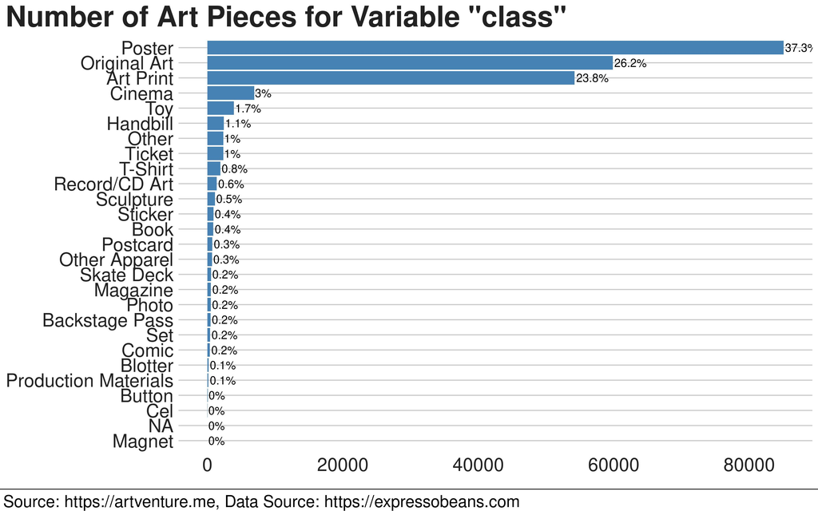

### Release Date

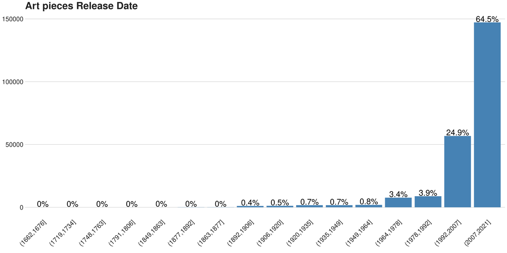

### Status

Almost 90% of the art in the data set is official, 5% is fan art created by fans of artists, musicians, an author or somthing similar.

To get an idea what Fan Art is the piece “Phish Englewood CO 00 Everett - 1st” from Michael Everett which average selling price was $2537.5.

[figure not shown]

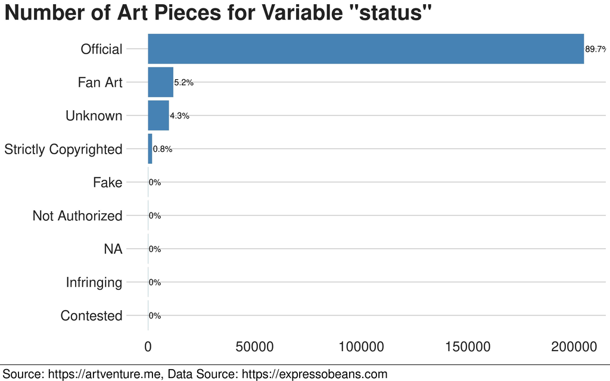

### Run

### Technique

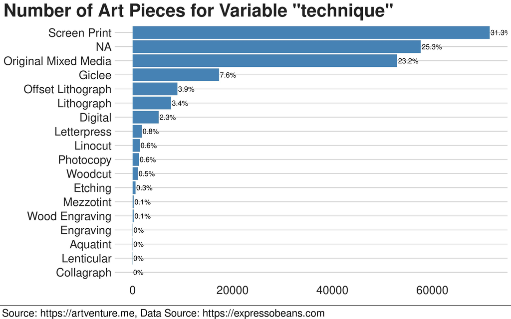

### Paper

### Width

### Height

### Markings

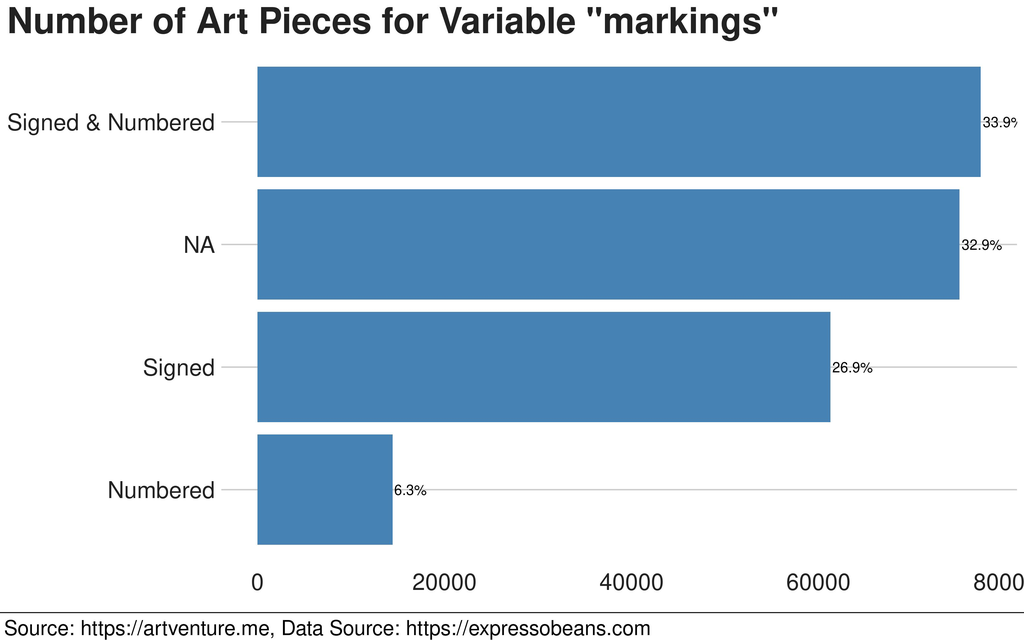

### Artwork’s name

### Artist’s name

### Artist’s pseudonym

### Original Price

### Collections

### Sold

### Six Month Average Price

### Average Price

### Lowest Price

### Highest Price